*Practical Machine Learning Course Project*  
*Rodney Gurdal*  
*July 24, 2016*

Introduction

Using devices such as Jawbone Up, Nike FuelBand, and Fitbit it is now possible to collect a large amount of data about personal activity relatively inexpensively. These type of devices are part of the quantified self movement - a group of enthusiasts who take measurements about themselves regularly to improve their health, to find patterns in their behavior, or because they are tech geeks. One thing that people regularly do is quantify how much of a particular activity they do, but they rarely quantify how well they do it. In this project, your goal will be to use data from accelerometers on the belt, forearm, arm, and dumbell of 6 participants. They were asked to perform barbell lifts correctly and incorrectly in 5 different ways. More information is available from the website here: http://groupware.les.inf.puc-rio.br/har (see the section on the Weight Lifting Exercise Dataset).

Data

The training data for this project are available here:

https://d396qusza40orc.cloudfront.net/predmachlearn/pml-training.csv

The test data are available here:

https://d396qusza40orc.cloudfront.net/predmachlearn/pml-testing.csv

Load libraries:

```r
library(caret)
library(rpart)
library(rattle)
library(e1071)
library(randomForest)
```

### Get the data, prepare the data

The “testingdata”" set is set aside. Model exploration and analysis are only performed on the “trainingdata”" set.

```r
filename1 <- "pml-training.csv"
fileURL1 <- "https://d396qusza40orc.cloudfront.net/predmachlearn/pml-training.csv"
if (!file.exists(filename1)){
  download.file(fileURL1, filename1, method="libcurl")
}
if (!file.exists("trainingdata")) {
  trainingdata <- read.csv("pml-training.csv")
}


filename2 <- "pml-testing.csv"
fileURL2 <- "https://d396qusza40orc.cloudfront.net/predmachlearn/pml-testing.csv"
if (!file.exists(filename2)){
  download.file(fileURL2, filename2, method="libcurl")
}
if (!file.exists("testingdata")) {
  testingdata <- read.csv("pml-testing.csv")
}
```

### Cross-Validation

Because we want to be able to estimate the out-of-sample error, we randomly split the full training data (trainingdata) into a smaller training set (trainingdata1) and a validation set (trainingdata2):

```r
set.seed(123)
inTrain <- createDataPartition(y=trainingdata$classe, p=0.7, list=F)
trainingdata1 <- trainingdata[inTrain, ]
trainingdata2 <- trainingdata[-inTrain, ]
```

The original dataset includes 19622 observations of 160 variables. Many of those variables, however, are not needed. We now reduce the dataset by removing variables with nearly zero variance, variables that are almost always NA, and variables that don’t make sense for prediction. After these variables are removed from “trainingdata1”, we remove the same ones from “trainingdata2”.

```r
# remove variables with nearly zero variance
nzv <- nearZeroVar(trainingdata1)
trainingdata1 <- trainingdata1[, -nzv]
trainingdata2 <- trainingdata2[, -nzv]

# remove variables that are almost always NA
mostlyNA <- sapply(trainingdata1, function(x) mean(is.na(x))) > 0.95
trainingdata1 <- trainingdata1[, mostlyNA==F]
trainingdata2 <- trainingdata2[, mostlyNA==F]

# remove variables that don't make  sense for prediction (user_name, etc.).
trainingdata1 <- trainingdata1[, -(1:5)]
trainingdata2 <- trainingdata2[, -(1:5)]
```

### Model

We start with a Random Forest model. We fit the model on trainingdata1, and instruct the “train” function to use 3-fold cross-validation to select optimal tuning parameters for the model.

```r
fitControl <- trainControl(method="cv", number=3)
RFfit <- train(classe ~ ., data=trainingdata1, method="rf", metric="Kappa", trControl=fitControl)
RFfit$finalModel
```

```
##
## Call:
##  randomForest(x = x, y = y, mtry = param$mtry)
##                Type of random forest: classification
##                      Number of trees: 500
## No. of variables tried at each split: 27
##
##         OOB estimate of  error rate: 0.19%
## Confusion matrix:
##      A    B    C    D    E  class.error
## A 3904    1    0    0    1 0.0005120328
## B    7 2649    2    0    0 0.0033860045
## C    0    3 2393    0    0 0.0012520868
## D    0    0    8 2243    1 0.0039964476
## E    0    0    0    3 2522 0.0011881188
```

We’ll also try a Gradient Boosting (gbm) model for comparison.

```r
GBMfit <- train(classe~., data=trainingdata1, method="gbm", metric="Kappa", trControl=fitControl,verbose=FALSE)
GBMfit$finalModel
```

```
## A gradient boosted model with multinomial loss function.
## 150 iterations were performed.
## There were 53 predictors of which 45 had non-zero influence.
```

The models are then compared using the resamples function from the Caret package.

```r
rValues <- resamples(list(rf=RFfit,gbm=GBMfit))
summary(rValues)
```

```
##
## Call:
## summary.resamples(object = rValues)
##
## Models: rf, gbm
## Number of resamples: 3
##
## Accuracy
##       Min. 1st Qu. Median   Mean 3rd Qu.   Max. NA's
## rf  0.9941  0.9948 0.9954 0.9960  0.9969 0.9985    0
## gbm 0.9834  0.9841 0.9847 0.9846  0.9851 0.9856    0
##
## Kappa
##       Min. 1st Qu. Median   Mean 3rd Qu.   Max. NA's
## rf  0.9925  0.9934 0.9942 0.9949  0.9961 0.9981    0
## gbm 0.9790  0.9798 0.9807 0.9805  0.9812 0.9818    0
```

### Plot the results

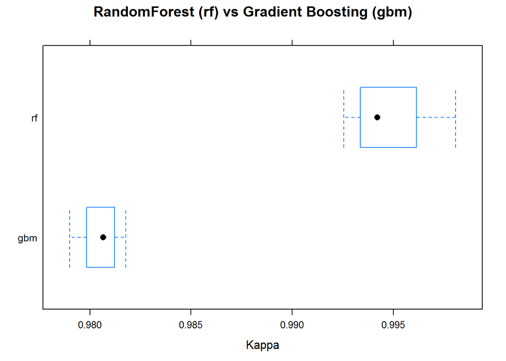

```r
bwplot(rValues,metric="Kappa",main="RandomForest (rf) vs Gradient Boosting (gbm)")
```

### Cross Validation

```r
#Training set:
trainingPred <- predict(RFfit, trainingdata1)
confusionMatrix(trainingPred, trainingdata1$classe)
```

```
## Confusion Matrix and Statistics
##
##           Reference
## Prediction    A    B    C    D    E
##          A 3906    0    0    0    0
##          B    0 2658    0    0    0
##          C    0    0 2396    0    0
##          D    0    0    0 2252    0
##          E    0    0    0    0 2525
##
## Overall Statistics
##
##                Accuracy : 1
##                  95% CI : (0.9997, 1)
##     No Information Rate : 0.2843
##     P-Value [Acc > NIR] : < 2.2e-16
##
##                   Kappa : 1
##  Mcnemar's Test P-Value : NA
##
## Statistics by Class:
##
##                      Class: A Class: B Class: C Class: D Class: E
## Sensitivity            1.0000   1.0000   1.0000   1.0000   1.0000
## Specificity            1.0000   1.0000   1.0000   1.0000   1.0000
## Pos Pred Value         1.0000   1.0000   1.0000   1.0000   1.0000
## Neg Pred Value         1.0000   1.0000   1.0000   1.0000   1.0000
## Prevalence             0.2843   0.1935   0.1744   0.1639   0.1838
## Detection Rate         0.2843   0.1935   0.1744   0.1639   0.1838
## Detection Prevalence   0.2843   0.1935   0.1744   0.1639   0.1838
## Balanced Accuracy      1.0000   1.0000   1.0000   1.0000   1.0000
```

```r
#Validation set:
cvPred <- predict(RFfit, trainingdata2)
confusionMatrix(cvPred, trainingdata2$classe)
```

```
## Confusion Matrix and Statistics
##
##           Reference
## Prediction    A    B    C    D    E
##          A 1674    3    0    0    0
##          B    0 1136    4    0    0
##          C    0    0 1022    4    0
##          D    0    0    0  959    0
##          E    0    0    0    1 1082
##
## Overall Statistics
##
##                Accuracy : 0.998
##                  95% CI : (0.9964, 0.9989)
##     No Information Rate : 0.2845
##     P-Value [Acc > NIR] : < 2.2e-16
##
##                   Kappa : 0.9974
##  Mcnemar's Test P-Value : NA
##
## Statistics by Class:
##
##                      Class: A Class: B Class: C Class: D Class: E
## Sensitivity            1.0000   0.9974   0.9961   0.9948   1.0000
## Specificity            0.9993   0.9992   0.9992   1.0000   0.9998
## Pos Pred Value         0.9982   0.9965   0.9961   1.0000   0.9991
## Neg Pred Value         1.0000   0.9994   0.9992   0.9990   1.0000
## Prevalence             0.2845   0.1935   0.1743   0.1638   0.1839
## Detection Rate         0.2845   0.1930   0.1737   0.1630   0.1839
## Detection Prevalence   0.2850   0.1937   0.1743   0.1630   0.1840
## Balanced Accuracy      0.9996   0.9983   0.9976   0.9974   0.9999
```

### Model Testing

```r
results <- predict(RFfit,newdata=testingdata)
print(as.data.frame(results))
```

```
##    results
## 1        B
## 2        A
## 3        B
## 4        A
## 5        A
## 6        E
## 7        D
## 8        B
## 9        A
## 10       A
## 11       B
## 12       C
## 13       B
## 14       A
## 15       E
## 16       E
## 17       A
## 18       B
## 19       B
## 20       B
```